# Telecomm Customer

Chukwuka Akibor

5/19/2021

#Installing and loading the package

```r
library(plyr)
library(corrplot)
library(ggplot2)
library(gridExtra)
library(ggthemes)
library(caret)
library(MASS)
library(randomForest)
library(party)
```

```r
# set up line wrapping in MD knit output
library(knitr)
hook_output = knit_hooks$get("output")
knit_hooks$set(output = function(x, options)
{
 # this hook is used only when the linewidth option is not NULL
 if (!is.null(n <- options$linewidth))
 {
 x = knitr:::split_lines(x)
 # any lines wider than n should be wrapped
 if (any(nchar(x) > n))
 x = strwrap(x, width = n)
 x = paste(x, collapse = "\n")
 }
 hook_output(x, options)
})
```

```r
filePath <- "/Volumes/Seagate_Haykay/customer_churn_R"
setwd(filePath)
getwd()
```

```
[1] "/Volumes/Seagate_Haykay/customer_churn_R"
```

#Reading the dataset file and checking the structure using str()

```r
Telco <- read.csv("Telco-Customer-Churn.csv")

str(Telco)
```

```
'data.frame':   7043 obs. of  21 variables:
 $ customerID      : chr  "7590-VHVEG" "5575-GNVDE" "3668-QPYBK" "7795-CFOCW" ...
 $ gender          : chr  "Female" "Male" "Male" "Male" ...
 $ SeniorCitizen   : int  0 0 0 0 0 0 0 0 0 0 ...
 $ Partner         : chr  "Yes" "No" "No" "No" ...
 $ Dependents      : chr  "No" "No" "No" "No" ...
 $ tenure          : int  1 34 2 45 2 8 22 10 28 62 ...
 $ PhoneService    : chr  "No" "Yes" "Yes" "No" ...
 $ MultipleLines   : chr  "No phone service" "No" "No" "No phone service" ...
 $ InternetService : chr  "DSL" "DSL" "DSL" "DSL" ...
 $ OnlineSecurity  : chr  "No" "Yes" "Yes" "Yes" ...
 $ OnlineBackup    : chr  "Yes" "No" "Yes" "No" ...
 $ DeviceProtection: chr  "No" "Yes" "No" "Yes" ...
 $ TechSupport     : chr  "No" "No" "No" "Yes" ...
 $ StreamingTV     : chr  "No" "No" "No" "No" ...
 $ StreamingMovies : chr  "No" "No" "No" "No" ...
 $ Contract        : chr  "Month-to-month" "One year" "Month-to-month" "One year" ...
 $ PaperlessBilling: chr  "Yes" "No" "Yes" "No" ...
 $ PaymentMethod   : chr  "Electronic check" "Mailed check" "Mailed check" "Bank transfer (automatic)" ...
 $ MonthlyCharges  : num  29.9 57 53.9 42.3 70.7 ...
 $ TotalCharges    : num  29.9 1889.5 108.2 1840.8 151.7 ...
 $ Churn           : chr  "No" "No" "Yes" "No" ...
```

#Check the number of missing values in each column

```r
sapply(Telco, function(x) sum(is.na(x)))
```

```
      customerID           gender    SeniorCitizen
               0                0                0
         Partner       Dependents           tenure
               0                0                0
    PhoneService    MultipleLines  InternetService
               0                0                0
  OnlineSecurity     OnlineBackup DeviceProtection
               0                0                0
     TechSupport      StreamingTV  StreamingMovies
               0                0                0
        Contract PaperlessBilling    PaymentMethod
               0                0                0
  MonthlyCharges     TotalCharges            Churn
               0               11                0
```

```r
Telco <- Telco[complete.cases(Telco), ]
head(Telco)
```

|  | customerID | gender | SeniorCitizen | Partner | Dependents | tenure | PhoneService | MultipleLines | InternetService | OnlineSecurity | OnlineBackup | DeviceProtection | TechSupport | StreamingTV | StreamingMovies | Contract | PaperlessBilling | PaymentMethod | MonthlyCharges | TotalCharges | Churn |
| --- | --- | --- | --- | --- | --- | --- | --- | --- | --- | --- | --- | --- | --- | --- | --- | --- | --- | --- | --- | --- | --- |
| 1 | 7590-VHVEG | Female | 0 | Yes | No | 1 | No | No phone service | DSL | No | Yes | No | No | No | No | Month-to-month | Yes | Electronic check | 29.85 | 29.85 | No |
| 2 | 5575-GNVDE | Male | 0 | No | No | 34 | Yes | No | DSL | Yes | No | Yes | No | No | No | One year | No | Mailed check | 56.95 | 1889.50 | No |
| 3 | 3668-QPYBK | Male | 0 | No | No | 2 | Yes | No | DSL | Yes | Yes | No | No | No | No | Month-to-month | Yes | Mailed check | 53.85 | 108.15 | Yes |
| 4 | 7795-CFOCW | Male | 0 | No | No | 45 | No | No phone service | DSL | Yes | No | Yes | Yes | No | No | One year | No | Bank transfer (automatic) | 42.30 | 1840.75 | No |
| 5 | 9237-HQITU | Female | 0 | No | No | 2 | Yes | No | Fiber optic | No | No | No | No | No | No | Month-to-month | Yes | Electronic check | 70.70 | 151.65 | Yes |
| 6 | 9305-CDSKC | Female | 0 | No | No | 8 | Yes | Yes | Fiber optic | No | No | Yes | No | Yes | Yes | Month-to-month | Yes | Electronic check | 99.65 | 820.50 | Yes |

# We will change “No internet service” to “No” for six columns, they are: “OnlineSecurity”, “OnlineBackup”, “DeviceProtection”, “TechSupport”, “streamingTV”, “streamingMovies”.

```r
cols_recode1 <- c(10:15)
for(i in 1:ncol(Telco[,cols_recode1])) {
        Telco[,cols_recode1][,i] <- as.factor(mapvalues
                                              (Telco[,cols_recode1][,i], from =c("No internet service"),to=c("No")))
}
```

# We will change “No phone service” to “No” for column “MultipleLines”

```r
Telco$MultipleLines <- as.factor(mapvalues(Telco$MultipleLines,
                                           from=c("No phone service"),
                                           to=c("No")))
```

#Since the minimum tenure is 1 month and maximum tenure is 72 months, we can group them into five tenure groups: “0–12 Month”, “12–24 Month”, “24–48 Months”, “48–60 Month”, “> 60 Month”

```r
min(Telco$tenure); max(Telco$tenure)
```

```
[1] 1
[1] 72
```

```r
group_tenure <- function(tenure){
    if (tenure >= 0 & tenure <= 12){
        return('0-12 Month')
    }else if(tenure > 12 & tenure <= 24){
        return('12-24 Month')
    }else if (tenure > 24 & tenure <= 48){
        return('24-48 Month')
    }else if (tenure > 48 & tenure <=60){
        return('48-60 Month')
    }else if (tenure > 60){
        return('> 60 Month')
    }
}
Telco$tenure_group <- sapply(Telco$tenure,group_tenure)
Telco$tenure_group <- as.factor(Telco$tenure_group)
```

# Change the values in column “SeniorCitizen” from 0 or 1 to “No” or “Yes”.

```r
head(Telco)
```

|  | customerID | gender | SeniorCitizen | Partner | Dependents | tenure | PhoneService | MultipleLines | InternetService | OnlineSecurity | OnlineBackup | DeviceProtection | TechSupport | StreamingTV | StreamingMovies | Contract | PaperlessBilling | PaymentMethod | MonthlyCharges | TotalCharges | Churn | tenure_group |
| --- | --- | --- | --- | --- | --- | --- | --- | --- | --- | --- | --- | --- | --- | --- | --- | --- | --- | --- | --- | --- | --- | --- |
| 1 | 7590-VHVEG | Female | 0 | Yes | No | 1 | No | No | DSL | No | Yes | No | No | No | No | Month-to-month | Yes | Electronic check | 29.85 | 29.85 | No | 0-12 Month |
| 2 | 5575-GNVDE | Male | 0 | No | No | 34 | Yes | No | DSL | Yes | No | Yes | No | No | No | One year | No | Mailed check | 56.95 | 1889.50 | No | 24-48 Month |
| 3 | 3668-QPYBK | Male | 0 | No | No | 2 | Yes | No | DSL | Yes | Yes | No | No | No | No | Month-to-month | Yes | Mailed check | 53.85 | 108.15 | Yes | 0-12 Month |
| 4 | 7795-CFOCW | Male | 0 | No | No | 45 | No | No | DSL | Yes | No | Yes | Yes | No | No | One year | No | Bank transfer (automatic) | 42.30 | 1840.75 | No | 24-48 Month |
| 5 | 9237-HQITU | Female | 0 | No | No | 2 | Yes | No | Fiber optic | No | No | No | No | No | No | Month-to-month | Yes | Electronic check | 70.70 | 151.65 | Yes | 0-12 Month |
| 6 | 9305-CDSKC | Female | 0 | No | No | 8 | Yes | Yes | Fiber optic | No | No | Yes | No | Yes | Yes | Month-to-month | Yes | Electronic check | 99.65 | 820.50 | Yes | 0-12 Month |

```r
Telco$SeniorCitizen <- as.factor(mapvalues(Telco$SeniorCitizen,
                                      from=c("0","1"),
                                      to=c("No", "Yes")))
```

#Removing the columns we do not require

```r
Telco$customerID <- NULL
Telco$tenure <- NULL
```

# Exploratory data analysis and feature selection

# Correlation between numeric variables

```r
head(Telco)
```

|  | gender | SeniorCitizen | Partner | Dependents | PhoneService | MultipleLines | InternetService | OnlineSecurity | OnlineBackup | DeviceProtection | TechSupport | StreamingTV | StreamingMovies | Contract | PaperlessBilling | PaymentMethod | MonthlyCharges | TotalCharges | Churn | tenure_group |
| --- | --- | --- | --- | --- | --- | --- | --- | --- | --- | --- | --- | --- | --- | --- | --- | --- | --- | --- | --- | --- |
| 1 | Female | No | Yes | No | No | No | DSL | No | Yes | No | No | No | No | Month-to-month | Yes | Electronic check | 29.85 | 29.85 | No | 0-12 Month |
| 2 | Male | No | No | No | Yes | No | DSL | Yes | No | Yes | No | No | No | One year | No | Mailed check | 56.95 | 1889.50 | No | 24-48 Month |
| 3 | Male | No | No | No | Yes | No | DSL | Yes | Yes | No | No | No | No | Month-to-month | Yes | Mailed check | 53.85 | 108.15 | Yes | 0-12 Month |
| 4 | Male | No | No | No | No | No | DSL | Yes | No | Yes | Yes | No | No | One year | No | Bank transfer (automatic) | 42.30 | 1840.75 | No | 24-48 Month |
| 5 | Female | No | No | No | Yes | No | Fiber optic | No | No | No | No | No | No | Month-to-month | Yes | Electronic check | 70.70 | 151.65 | Yes | 0-12 Month |
| 6 | Female | No | No | No | Yes | Yes | Fiber optic | No | No | Yes | No | Yes | Yes | Month-to-month | Yes | Electronic check | 99.65 | 820.50 | Yes | 0-12 Month |

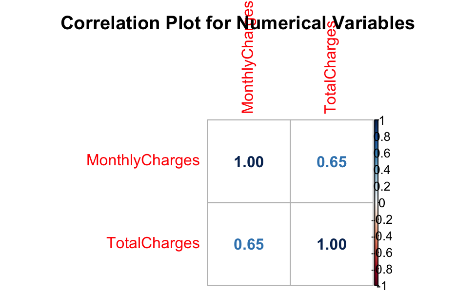

```r
numeric.var <- sapply(Telco, is.numeric)
corr.matrix <- cor(Telco[,numeric.var])
corrplot(corr.matrix, main="\n\nCorrelation Plot for Numerical Variables", method="number")
```

# The Monthly Charges and Total Charges are correlated. So one of them will be removed from the model. We remove Total Charges.

```r
Telco$TotalCharges <- NULL
```

#Bar plots of categorical variables

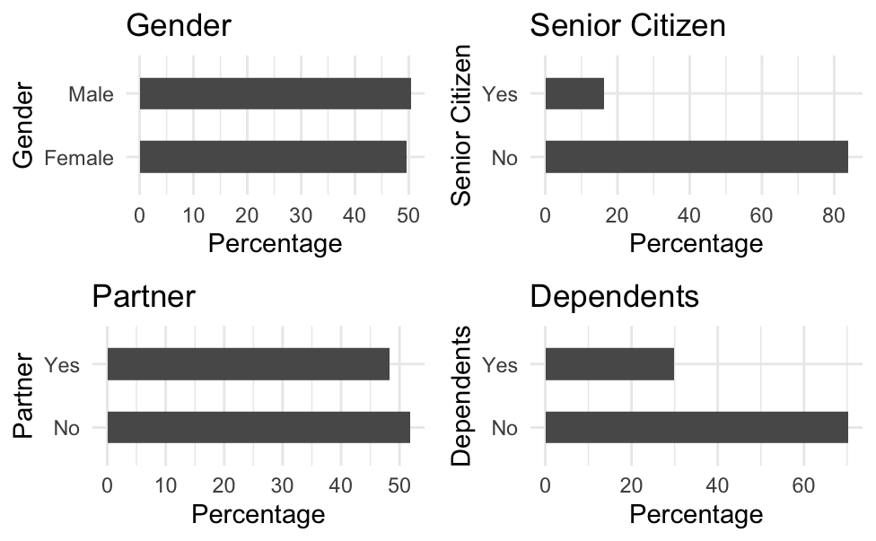

```r
p1 <- ggplot(Telco, aes(x=gender)) + ggtitle("Gender") + xlab("Gender") +
  geom_bar(aes(y = 100*(..count..)/sum(..count..)), width = 0.5) + ylab("Percentage") + coord_flip() + theme_minimal()

p2 <- ggplot(Telco, aes(x=SeniorCitizen)) + ggtitle("Senior Citizen") + xlab("Senior Citizen") +
  geom_bar(aes(y = 100*(..count..)/sum(..count..)), width = 0.5) + ylab("Percentage") + coord_flip() + theme_minimal()

p3 <- ggplot(Telco, aes(x=Partner)) + ggtitle("Partner") + xlab("Partner") +
  geom_bar(aes(y = 100*(..count..)/sum(..count..)), width = 0.5) + ylab("Percentage") + coord_flip() + theme_minimal()

p4 <- ggplot(Telco, aes(x=Dependents)) + ggtitle("Dependents") + xlab("Dependents") +
  geom_bar(aes(y = 100*(..count..)/sum(..count..)), width = 0.5) + ylab("Percentage") + coord_flip() + theme_minimal()
grid.arrange(p1, p2, p3, p4, ncol=2)
```

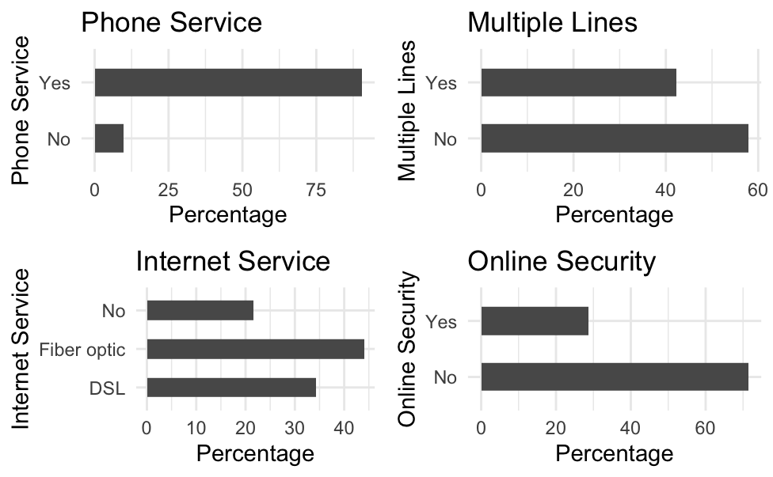

```r
p5 <- ggplot(Telco, aes(x=PhoneService)) + ggtitle("Phone Service") + xlab("Phone Service") +
  geom_bar(aes(y = 100*(..count..)/sum(..count..)), width = 0.5) + ylab("Percentage") + coord_flip() + theme_minimal()

p6 <- ggplot(Telco, aes(x=MultipleLines)) + ggtitle("Multiple Lines") + xlab("Multiple Lines") +
  geom_bar(aes(y = 100*(..count..)/sum(..count..)), width = 0.5) + ylab("Percentage") + coord_flip() + theme_minimal()

p7 <- ggplot(Telco, aes(x=InternetService)) + ggtitle("Internet Service") + xlab("Internet Service") +
  geom_bar(aes(y = 100*(..count..)/sum(..count..)), width = 0.5) + ylab("Percentage") + coord_flip() + theme_minimal()

p8 <- ggplot(Telco, aes(x=OnlineSecurity)) + ggtitle("Online Security") + xlab("Online Security") +
  geom_bar(aes(y = 100*(..count..)/sum(..count..)), width = 0.5) + ylab("Percentage") + coord_flip() + theme_minimal()
grid.arrange(p5, p6, p7, p8, ncol=2)
```

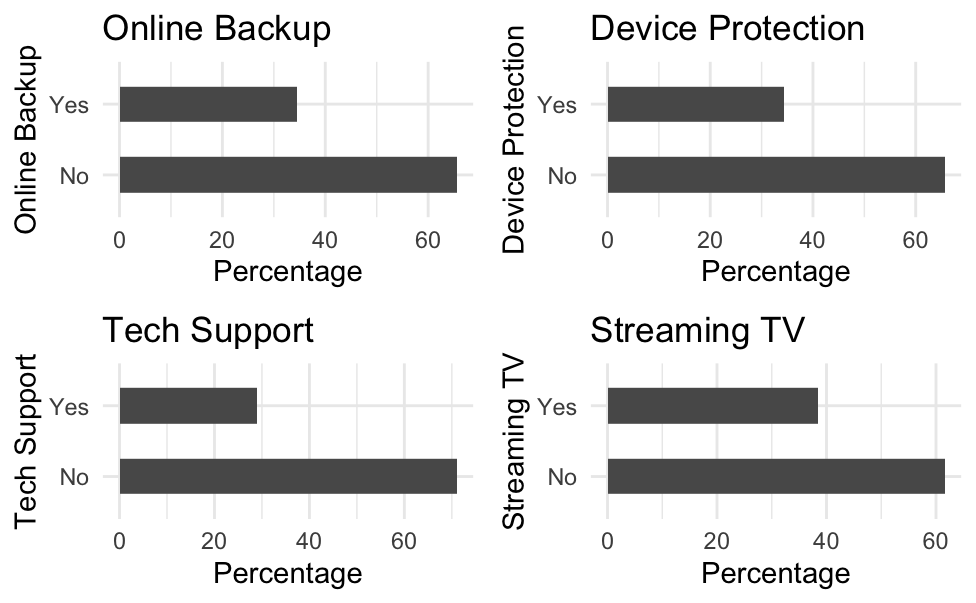

```r
p9 <- ggplot(Telco, aes(x=OnlineBackup)) + ggtitle("Online Backup") + xlab("Online Backup") +
  geom_bar(aes(y = 100*(..count..)/sum(..count..)), width = 0.5) + ylab("Percentage") + coord_flip() + theme_minimal()

p10 <- ggplot(Telco, aes(x=DeviceProtection)) + ggtitle("Device Protection") + xlab("Device Protection") +
  geom_bar(aes(y = 100*(..count..)/sum(..count..)), width = 0.5) + ylab("Percentage") + coord_flip() + theme_minimal()

p11 <- ggplot(Telco, aes(x=TechSupport)) + ggtitle("Tech Support") + xlab("Tech Support") +
  geom_bar(aes(y = 100*(..count..)/sum(..count..)), width = 0.5) + ylab("Percentage") + coord_flip() + theme_minimal()

p12 <- ggplot(Telco, aes(x=StreamingTV)) + ggtitle("Streaming TV") + xlab("Streaming TV") +
  geom_bar(aes(y = 100*(..count..)/sum(..count..)), width = 0.5) + ylab("Percentage") + coord_flip() + theme_minimal()
grid.arrange(p9, p10, p11, p12, ncol=2)
```

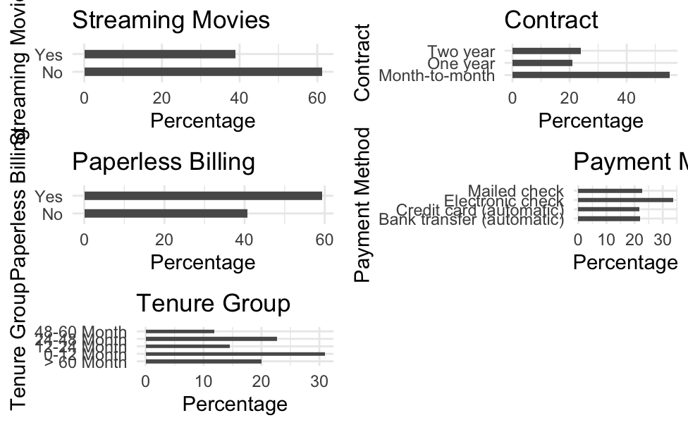

```r
p13 <- ggplot(Telco, aes(x=StreamingMovies)) + ggtitle("Streaming Movies") + xlab("Streaming Movies") +
  geom_bar(aes(y = 100*(..count..)/sum(..count..)), width = 0.5) + ylab("Percentage") + coord_flip() + theme_minimal()

p14 <- ggplot(Telco, aes(x=Contract)) + ggtitle("Contract") + xlab("Contract") +
  geom_bar(aes(y = 100*(..count..)/sum(..count..)), width = 0.5) + ylab("Percentage") + coord_flip() + theme_minimal()

p15 <- ggplot(Telco, aes(x=PaperlessBilling)) + ggtitle("Paperless Billing") + xlab("Paperless Billing") +
  geom_bar(aes(y = 100*(..count..)/sum(..count..)), width = 0.5) + ylab("Percentage") + coord_flip() + theme_minimal()

p16 <- ggplot(Telco, aes(x=PaymentMethod)) + ggtitle("Payment Method") + xlab("Payment Method") +
  geom_bar(aes(y = 100*(..count..)/sum(..count..)), width = 0.5) + ylab("Percentage") + coord_flip() + theme_minimal()

p17 <- ggplot(Telco, aes(x=tenure_group)) + ggtitle("Tenure Group") + xlab("Tenure Group") +
  geom_bar(aes(y = 100*(..count..)/sum(..count..)), width = 0.5) + ylab("Percentage") + coord_flip() + theme_minimal()
grid.arrange(p13, p14, p15, p16, p17, ncol=2)
```

#### Logistic Regression

#We will split the dataset into Train and Test dataset

```r
trn<- createDataPartition(Telco$Churn,p=0.7,list=FALSE)
head(trn)
```

```
     Resample1
[1,]         1
[2,]         4
[3,]         6
[4,]         7
[5,]        10
[6,]        11
```

```r
set.seed(2017)
training<- Telco[trn,]
head(training)
```

|  | gender | SeniorCitizen | Partner | Dependents | PhoneService | MultipleLines | InternetService | OnlineSecurity | OnlineBackup | DeviceProtection | TechSupport | StreamingTV | StreamingMovies | Contract | PaperlessBilling | PaymentMethod | MonthlyCharges | Churn | tenure_group |
| --- | --- | --- | --- | --- | --- | --- | --- | --- | --- | --- | --- | --- | --- | --- | --- | --- | --- | --- | --- |
| 1 | Female | No | Yes | No | No | No | DSL | No | Yes | No | No | No | No | Month-to-month | Yes | Electronic check | 29.85 | No | 0-12 Month |
| 4 | Male | No | No | No | No | No | DSL | Yes | No | Yes | Yes | No | No | One year | No | Bank transfer (automatic) | 42.30 | No | 24-48 Month |
| 6 | Female | No | No | No | Yes | Yes | Fiber optic | No | No | Yes | No | Yes | Yes | Month-to-month | Yes | Electronic check | 99.65 | Yes | 0-12 Month |
| 7 | Male | No | No | Yes | Yes | Yes | Fiber optic | No | Yes | No | No | Yes | No | Month-to-month | Yes | Credit card (automatic) | 89.10 | No | 12-24 Month |
| 10 | Male | No | No | Yes | Yes | No | DSL | Yes | Yes | No | No | No | No | One year | No | Bank transfer (automatic) | 56.15 | No | > 60 Month |
| 11 | Male | No | Yes | Yes | Yes | No | DSL | Yes | No | No | No | No | No | Month-to-month | Yes | Mailed check | 49.95 | No | 12-24 Month |

```r
testing<- Telco[-trn,]
head(testing)
```

|  | gender | SeniorCitizen | Partner | Dependents | PhoneService | MultipleLines | InternetService | OnlineSecurity | OnlineBackup | DeviceProtection | TechSupport | StreamingTV | StreamingMovies | Contract | PaperlessBilling | PaymentMethod | MonthlyCharges | Churn | tenure_group |
| --- | --- | --- | --- | --- | --- | --- | --- | --- | --- | --- | --- | --- | --- | --- | --- | --- | --- | --- | --- |
| 2 | Male | No | No | No | Yes | No | DSL | Yes | No | Yes | No | No | No | One year | No | Mailed check | 56.95 | No | 24-48 Month |
| 3 | Male | No | No | No | Yes | No | DSL | Yes | Yes | No | No | No | No | Month-to-month | Yes | Mailed check | 53.85 | Yes | 0-12 Month |
| 5 | Female | No | No | No | Yes | No | Fiber optic | No | No | No | No | No | No | Month-to-month | Yes | Electronic check | 70.70 | Yes | 0-12 Month |
| 8 | Female | No | No | No | No | No | DSL | Yes | No | No | No | No | No | Month-to-month | No | Mailed check | 29.75 | No | 0-12 Month |
| 9 | Female | No | Yes | No | Yes | Yes | Fiber optic | No | No | Yes | Yes | Yes | Yes | Month-to-month | Yes | Electronic check | 104.80 | Yes | 24-48 Month |
| 12 | Male | No | No | No | Yes | No | No | No | No | No | No | No | No | Two year | No | Credit card (automatic) | 18.95 | No | 12-24 Month |

Confirm the splitting is correct:

```r
dim(training); dim(testing)
```

```
[1] 4924   19
[1] 2108   19
```

#Now, we will try to fit the model within the glm() for logistic regression

```r
L_Model <- glm(as.factor(Churn) ~ .,family=binomial(link="logit"),data=training)
print(summary(L_Model))
```

```
Call:
glm(formula = as.factor(Churn) ~ ., family = binomial(link = "logit"),
    data = training)

Deviance Residuals:
    Min       1Q   Median       3Q      Max
-1.9526  -0.6720  -0.2969   0.6873   3.1580

Coefficients:
                                      Estimate Std. Error
(Intercept)                          -0.457307   0.974418
genderMale                           -0.061005   0.077471
SeniorCitizenYes                      0.221947   0.100524
PartnerYes                            0.008675   0.092088
DependentsYes                        -0.131064   0.106127
PhoneServiceYes                       0.847354   0.768306
MultipleLinesYes                      0.616466   0.210822
InternetServiceFiber optic            2.546133   0.943249
InternetServiceNo                    -2.453611   0.956195
OnlineSecurityYes                     0.024894   0.212055
OnlineBackupYes                       0.176830   0.207607
DeviceProtectionYes                   0.345717   0.207698
TechSupportYes                        0.097362   0.213556
StreamingTVYes                        0.847498   0.385818
StreamingMoviesYes                    0.830193   0.386362
ContractOne year                     -0.752623   0.128280
ContractTwo year                     -1.681344   0.213975
PaperlessBillingYes                   0.377118   0.088917
PaymentMethodCredit card (automatic) -0.035470   0.135406
PaymentMethodElectronic check         0.349671   0.112370
PaymentMethodMailed check             0.029303   0.136404
MonthlyCharges                       -0.063569   0.037525
tenure_group0-12 Month                1.680055   0.200834
tenure_group12-24 Month               0.790108   0.196485
tenure_group24-48 Month               0.380327   0.178519
tenure_group48-60 Month               0.027112   0.198716
                                     z value Pr(>|z|)
(Intercept)                           -0.469  0.63885
genderMale                            -0.787  0.43101
SeniorCitizenYes                       2.208  0.02725 *
```

[output cut: 18 more lines]

```
MonthlyCharges                        -1.694  0.09026 .
tenure_group0-12 Month                 8.365  < 2e-16 ***
tenure_group12-24 Month                4.021 5.79e-05 ***
tenure_group24-48 Month                2.130  0.03313 *
tenure_group48-60 Month                0.136  0.89148
---
Signif. codes:  0 ‘***’ 0.001 ‘**’ 0.01 ‘*’ 0.05 ‘.’ 0.1 ‘ ’ 1

(Dispersion parameter for binomial family taken to be 1)

    Null deviance: 5702.8  on 4923  degrees of freedom
Residual deviance: 4109.6  on 4898  degrees of freedom
AIC: 4161.6

Number of Fisher Scoring iterations: 6
```

# Feature Analysis:

# The top three most-relevant features include Contract, tenure_group and PaperlessBilling.

#Analyzing the model further on few more features

```r
anova(L_Model, test="Chisq")
```

```
Analysis of Deviance Table

Model: binomial, link: logit

Response: as.factor(Churn)

Terms added sequentially (first to last)

                 Df Deviance Resid. Df Resid. Dev  Pr(>Chi)
NULL                              4923     5702.8
gender            1     1.37      4922     5701.4   0.24170
SeniorCitizen     1    99.76      4921     5601.6 < 2.2e-16 ***
Partner           1   104.83      4920     5496.8 < 2.2e-16 ***
Dependents        1    33.85      4919     5463.0 5.965e-09 ***
PhoneService      1     1.29      4918     5461.7   0.25677
MultipleLines     1     5.91      4917     5455.8   0.01502 *
InternetService   2   513.61      4915     4942.1 < 2.2e-16 ***
OnlineSecurity    1   154.74      4914     4787.4 < 2.2e-16 ***
OnlineBackup      1    75.29      4913     4712.1 < 2.2e-16 ***
DeviceProtection  1    34.54      4912     4677.6 4.183e-09 ***
TechSupport       1    62.16      4911     4615.4 3.169e-15 ***
StreamingTV       1     0.07      4910     4615.3   0.79018
StreamingMovies   1     0.00      4909     4615.3   0.99865
Contract          2   286.16      4907     4329.2 < 2.2e-16 ***
PaperlessBilling  1    18.17      4906     4311.0 2.021e-05 ***
PaymentMethod     3    34.60      4903     4276.4 1.478e-07 ***
MonthlyCharges    1     2.70      4902     4273.7   0.10063
tenure_group      4   164.15      4898     4109.6 < 2.2e-16 ***
---
Signif. codes:  0 ‘***’ 0.001 ‘**’ 0.01 ‘*’ 0.05 ‘.’ 0.1 ‘ ’ 1
```

Analyzing the deviance table we can see the drop in deviance when adding each variable one at a time. Adding InternetService, Contract and tenure_group significantly reduces the residual deviance. The other variables such as PaymentMethod and Dependents seem to improve the model less even though they all have low p-values.

```r
L_Model
```

[output not shown]

#Now we will evaluate the predictive ability of the Logistic Regression model

```r
testing$Churn <- as.character(testing$Churn)

testing$Churn[testing$Churn=="No"] <- "0"

testing$Churn[testing$Churn=="Yes"] <- "1"

FitResult <- predict(L_Model,newdata=testing,type='response')

FitResult <- ifelse(FitResult > 0.5,1,0)

MisClassificationError <- mean(FitResult != testing$Churn)

print(paste('Accuracy of Logistic Regression',1-MisClassificationError))
```

```
[1] "Accuracy of Logistic Regression 0.804079696394687"
```

#Lets make a confusion matrix for the logistic regression performed above

```r
print("Logistic Regression Confusion Matrix"); table(testing$Churn, FitResult > 0.5)
```

```
[1] "Logistic Regression Confusion Matrix"

    FALSE TRUE
  0  1411  137
  1   276  284
```

# Odds Ratio

One of the interesting performance measurements in logistic regression is Odds Ratio.Basically, Odds ratio is what the odds of an event is happening.

```r
exp(cbind(OR=coef(L_Model), confint(L_Model)))
```

```
                                              OR      2.5 %
(Intercept)                           0.63298589 0.09369507
genderMale                            0.94081862 0.80824165
SeniorCitizenYes                      1.24850532 1.02500934
PartnerYes                            1.00871233 0.84221554
DependentsYes                         0.87716200 0.71193643
PhoneServiceYes                       2.33346431 0.51803037
MultipleLinesYes                      1.85236982 1.22602501
InternetServiceFiber optic           12.75767108 2.01443767
InternetServiceNo                     0.08598256 0.01316262
OnlineSecurityYes                     1.02520672 0.67636450
OnlineBackupYes                       1.19342849 0.79453919
DeviceProtectionYes                   1.41300216 0.94067759
TechSupportYes                        1.10225952 0.72517165
StreamingTVYes                        2.33380018 1.09664115
StreamingMoviesYes                    2.29376138 1.07665965
ContractOne year                      0.47112935 0.36529848
ContractTwo year                      0.18612369 0.12081709
PaperlessBillingYes                   1.45807638 1.22531271
PaymentMethodCredit card (automatic)  0.96515217 0.73991877
PaymentMethodElectronic check         1.41860038 1.13910486
PaymentMethodMailed check             1.02973637 0.78845224
MonthlyCharges                        0.93840983 0.87176275
tenure_group0-12 Month                5.36585181 3.63178198
tenure_group12-24 Month               2.20363533 1.50285430
tenure_group24-48 Month               1.46276235 1.03353617
tenure_group48-60 Month               1.02748295 0.69540694
                                         97.5 %
(Intercept)                           4.2763646
genderMale                            1.0951003
SeniorCitizenYes                      1.5202176
PartnerYes                            1.2084642
DependentsYes                         1.0793874
PhoneServiceYes                      10.5370557
MultipleLinesYes                      2.8022847
InternetServiceFiber optic           81.3637903
InternetServiceNo                     0.5593282
OnlineSecurityYes                     1.5534537
OnlineBackupYes                       1.7933023
DeviceProtectionYes                   2.1239030
TechSupportYes                        1.6753782
StreamingTVYes                        4.9783199
StreamingMoviesYes                    4.8980472
ContractOne year                      0.6042022
ContractTwo year                      0.2799501
PaperlessBillingYes                   1.7364498
PaymentMethodCredit card (automatic)  1.2583945
PaymentMethodElectronic check         1.7698873
PaymentMethodMailed check             1.3461058
MonthlyCharges                        1.0099507
tenure_group0-12 Month                7.9841190
tenure_group12-24 Month               3.2482233
tenure_group24-48 Month               2.0821718
tenure_group48-60 Month               1.5167424
```

#### Decision Tree

#Creating a decision tree

For illustration purpose, we are going to use only three variables for plotting Decision Trees, they are “Contract”, “tenure_group” and “PaperlessBilling”.

```r
str(training)
```

```
'data.frame':   4924 obs. of  19 variables:
 $ gender          : chr  "Female" "Male" "Female" "Male" ...
 $ SeniorCitizen   : Factor w/ 2 levels "No","Yes": 1 1 1 1 1 1 1 1 1 1 ...
 $ Partner         : chr  "Yes" "No" "No" "No" ...
 $ Dependents      : chr  "No" "No" "No" "Yes" ...
 $ PhoneService    : chr  "No" "No" "Yes" "Yes" ...
 $ MultipleLines   : Factor w/ 2 levels "No","Yes": 1 1 2 2 1 1 2 2 1 2 ...
 $ InternetService : chr  "DSL" "DSL" "Fiber optic" "Fiber optic" ...
 $ OnlineSecurity  : Factor w/ 2 levels "No","Yes": 1 2 1 1 2 2 1 1 2 2 ...
 $ OnlineBackup    : Factor w/ 2 levels "No","Yes": 2 1 1 2 2 1 1 2 1 2 ...
 $ DeviceProtection: Factor w/ 2 levels "No","Yes": 1 2 2 1 1 1 2 2 2 2 ...
 $ TechSupport     : Factor w/ 2 levels "No","Yes": 1 2 1 1 1 1 1 1 2 2 ...
 $ StreamingTV     : Factor w/ 2 levels "No","Yes": 1 1 2 2 1 1 2 2 2 2 ...
 $ StreamingMovies : Factor w/ 2 levels "No","Yes": 1 1 2 1 1 1 2 2 2 2 ...
 $ Contract        : chr  "Month-to-month" "One year" "Month-to-month" "Month-to-month" ...
 $ PaperlessBilling: chr  "Yes" "No" "Yes" "Yes" ...
 $ PaymentMethod   : chr  "Electronic check" "Bank transfer (automatic)" "Electronic check" "Credit card (automatic)" ...
 $ MonthlyCharges  : num  29.9 42.3 99.7 89.1 56.1 ...
 $ Churn           : chr  "No" "No" "Yes" "No" ...
 $ tenure_group    : Factor w/ 5 levels "> 60 Month","0-12 Month",..: 2 4 2 3 1 3 5 5 4 1 ...
```

```r
training$Churn <- factor(training$Churn)
training$Contract <- factor(training$Contract)
training$PaperlessBilling <- factor(training$PaperlessBilling)

 tree <- ctree(Churn~Contract+tenure_group+PaperlessBilling, training)
```

#Plotting the decision tree created above

```r
tree
```

```
     Conditional inference tree with 9 terminal nodes

Response:  Churn
Inputs:  Contract, tenure_group, PaperlessBilling
Number of observations:  4924

1) Contract == {One year, Two year}; criterion = 1, statistic = 803.021
  2) Contract == {Two year}; criterion = 1, statistic = 57.4
    3) PaperlessBilling == {No}; criterion = 0.988, statistic = 8.27
      4)*  weights = 636
    3) PaperlessBilling == {Yes}
      5)*  weights = 540
  2) Contract == {One year}
    6) PaperlessBilling == {Yes}; criterion = 1, statistic = 17.322
      7)*  weights = 542
    6) PaperlessBilling == {No}
      8)*  weights = 469
1) Contract == {Month-to-month}
  9) tenure_group == {0-12 Month}; criterion = 1, statistic = 92.939
    10) PaperlessBilling == {No}; criterion = 1, statistic = 71.889
      11)*  weights = 544
    10) PaperlessBilling == {Yes}
      12)*  weights = 864
  9) tenure_group == {> 60 Month, 12-24 Month, 24-48 Month, 48-60 Month}
    13) PaperlessBilling == {No}; criterion = 1, statistic = 30.994
      14)*  weights = 376
    13) PaperlessBilling == {Yes}
      15) tenure_group == {> 60 Month, 48-60 Month}; criterion = 0.982, statistic = 12.409
        16)*  weights = 190
      15) tenure_group == {12-24 Month, 24-48 Month}
        17)*  weights = 763
```

[figure not shown]

```r
plot(tree)
```

1. Out of three variables we use, Contract is the most important variable to predict customer churn or not churn.
2. If a customer in a one-year or two-year contract, no matter he (she) has PapelessBilling or not, he (she) is less likely to churn.
3. On the other hand, if a customer is in a month-to-month contract, and in the tenure group of 0–12 month, and using PaperlessBilling, then this customer is more likely to churn.

#Predicting the result and making a confusion matrix for decision tree

```r
tree
```

```
     Conditional inference tree with 9 terminal nodes

Response:  Churn
Inputs:  Contract, tenure_group, PaperlessBilling
Number of observations:  4924

1) Contract == {One year, Two year}; criterion = 1, statistic = 803.021
  2) Contract == {Two year}; criterion = 1, statistic = 57.4
    3) PaperlessBilling == {No}; criterion = 0.988, statistic = 8.27
      4)*  weights = 636
    3) PaperlessBilling == {Yes}
      5)*  weights = 540
  2) Contract == {One year}
    6) PaperlessBilling == {Yes}; criterion = 1, statistic = 17.322
      7)*  weights = 542
    6) PaperlessBilling == {No}
      8)*  weights = 469
1) Contract == {Month-to-month}
  9) tenure_group == {0-12 Month}; criterion = 1, statistic = 92.939
    10) PaperlessBilling == {No}; criterion = 1, statistic = 71.889
      11)*  weights = 544
    10) PaperlessBilling == {Yes}
      12)*  weights = 864
  9) tenure_group == {> 60 Month, 12-24 Month, 24-48 Month, 48-60 Month}
    13) PaperlessBilling == {No}; criterion = 1, statistic = 30.994
      14)*  weights = 376
    13) PaperlessBilling == {Yes}
      15) tenure_group == {> 60 Month, 48-60 Month}; criterion = 0.982, statistic = 12.409
        16)*  weights = 190
      15) tenure_group == {12-24 Month, 24-48 Month}
        17)*  weights = 763
```

```r
testing
```

[output not shown]

[output cut: 990 more lines]

```r
str(testing)
```

```
'data.frame':   2108 obs. of  19 variables:
 $ gender          : chr  "Male" "Male" "Female" "Female" ...
 $ SeniorCitizen   : Factor w/ 2 levels "No","Yes": 1 1 1 1 1 1 1 1 1 2 ...
 $ Partner         : chr  "No" "No" "No" "No" ...
 $ Dependents      : chr  "No" "No" "No" "No" ...
 $ PhoneService    : chr  "Yes" "Yes" "Yes" "No" ...
 $ MultipleLines   : Factor w/ 2 levels "No","Yes": 1 1 1 1 2 1 1 2 1 1 ...
 $ InternetService : chr  "DSL" "DSL" "Fiber optic" "DSL" ...
 $ OnlineSecurity  : Factor w/ 2 levels "No","Yes": 2 2 1 2 1 1 1 1 2 1 ...
 $ OnlineBackup    : Factor w/ 2 levels "No","Yes": 1 2 1 1 1 1 1 2 2 1 ...
 $ DeviceProtection: Factor w/ 2 levels "No","Yes": 2 1 1 1 2 1 1 1 2 1 ...
 $ TechSupport     : Factor w/ 2 levels "No","Yes": 1 1 1 1 2 1 1 2 2 1 ...
 $ StreamingTV     : Factor w/ 2 levels "No","Yes": 1 1 1 1 2 1 1 1 1 1 ...
 $ StreamingMovies : Factor w/ 2 levels "No","Yes": 1 1 1 1 2 1 1 1 1 1 ...
 $ Contract        : chr  "One year" "Month-to-month" "Month-to-month" "Month-to-month" ...
 $ PaperlessBilling: chr  "No" "Yes" "Yes" "No" ...
 $ PaymentMethod   : chr  "Mailed check" "Mailed check" "Electronic check" "Mailed check" ...
 $ MonthlyCharges  : num  57 53.9 70.7 29.8 104.8 ...
 $ Churn           : chr  "0" "1" "1" "0" ...
 $ tenure_group    : Factor w/ 5 levels "> 60 Month","0-12 Month",..: 4 2 2 2 4 3 2 5 4 2 ...
```

```r
testing$Churn <- factor(testing$Churn)
testing$Contract <- factor(testing$Contract)
testing$PaperlessBilling <- factor(testing$PaperlessBilling)
```

```r
pred_tree <- predict(tree, testing)

print("Decision Tree Confusion Matrix"); table(Predicted = pred_tree, Actual = testing$Churn)
```

```
[1] "Decision Tree Confusion Matrix"
         Actual
Predicted    0    1
      No  1398  342
      Yes  150  218
```

#Checking the accuracy of the decision tree

```r
pred1 <- predict(tree, training)
#pred1

table1 <- table(Predicted = pred1, Actual = training$Churn)
#table1

table2 <- table(Predicted = pred_tree, Actual = testing$Churn)
#table2
```

#Printing the accuracy result

```r
print(paste('Accuracy of Decision Tree', sum(diag(table2))/sum(table2)))
```

```
[1] "Accuracy of Decision Tree 0.766603415559772"
```